# Final models and Tables/Figures

Christoph Völtzke

2023

## packages

```r
library(readr) # read data
library(tidyverse) # data manipulation
library(RColorBrewer) # color palettes
library(xtable) # latex code for main results
library(yardstick) # ROC curves with multiple curves
library(stargazer) # latex code for descriptive stats
library(data.table) # data frame preparation for descriptive stats
```

# Information

## Load Helper functions needed for analysis

```r
source("Functions/calibration_helper.R")
# helper function to make calibration plots
```

## All data sets needed for Main results

Load all results on evaluation metrics obtained by the model building scripts when run with different folds indicated by document name.

```r
# All produced data frames from the Model building docs
full <- read_csv("Data/all_models_full_123.csv") # 1. fold
life <- read_csv("Data/all_models_lifestyle_123.csv") # 1. fold

full_1 <- read_csv("Data/all_models_full_41263.csv") # 2. fold
life_1 <- read_csv("Data/all_models_lifestyle_41263.csv") # 2. fold

full_2 <- read_csv("Data/all_models_full_2408.csv") # 3. fold
life_2 <- read_csv("Data/all_models_lifestyle_2408.csv") # 3. fold
```

### Overview - Full data over Folds

```r
# comparison of estimates over different folds
full[1:10,]
```

```
## # A tibble: 10 × 7
##    model           AUC Sensitivity Specificity Accuracy ML    Condition
##    <chr>         <dbl>       <dbl>       <dbl>    <dbl> <chr> <chr>
##  1 original      0.925       0.423       0.974    0.893 RF    Full_data
##  2 original_cost 0.925       0.885       0.842    0.848 RF    Full_data
##  3 smote_def     0.897       0.923       0.75     0.775 RF    Full_data
##  4 up_def        0.902       0.846       0.816    0.82  RF    Full_data
##  5 up_own        0.893       0.923       0.737    0.764 RF    Full_data
##  6 smote_own     0.914       0.923       0.783    0.803 RF    Full_data
##  7 original_own  0.927       0.923       0.809    0.826 RF    Full_data
##  8 up_ran        0.866       0.885       0.697    0.725 RF    Full_data
##  9 smote_ran     0.868       0.885       0.73     0.753 RF    Full_data
## 10 original_ran  0.93        0.885       0.888    0.888 RF    Full_data
```

```r
full_1[1:10,]
```

```
## # A tibble: 10 × 7
##    model           AUC Sensitivity Specificity Accuracy ML    Condition
##    <chr>         <dbl>       <dbl>       <dbl>    <dbl> <chr> <chr>
##  1 original      0.854       0.108       1        0.815 RF    Full_data
##  2 original_cost 0.854       0.838       0.716    0.742 RF    Full_data
##  3 smote_def     0.879       0.811       0.837    0.831 RF    Full_data
##  4 up_def        0.876       0.838       0.773    0.787 RF    Full_data
##  5 up_own        0.883       0.838       0.752    0.77  RF    Full_data
##  6 smote_own     0.866       0.865       0.709    0.742 RF    Full_data
##  7 original_own  0.865       0.811       0.759    0.77  RF    Full_data
##  8 up_ran        0.887       0.865       0.759    0.781 RF    Full_data
##  9 smote_ran     0.891       0.865       0.809    0.82  RF    Full_data
## 10 original_ran  0.869       0.811       0.816    0.815 RF    Full_data
```

```r
full_2[1:10,]
```

```
## # A tibble: 10 × 7
##    model           AUC Sensitivity Specificity Accuracy ML    Condition
##    <chr>         <dbl>       <dbl>       <dbl>    <dbl> <chr> <chr>
##  1 original      0.908       0.464       0.94     0.865 RF    Full_data
##  2 original_cost 0.908       0.929       0.787    0.809 RF    Full_data
##  3 smote_def     0.872       0.893       0.76     0.781 RF    Full_data
##  4 up_def        0.876       0.857       0.793    0.803 RF    Full_data
##  5 up_own        0.879       0.893       0.753    0.775 RF    Full_data
##  6 smote_own     0.834       0.893       0.693    0.725 RF    Full_data
##  7 original_own  0.92        0.929       0.8      0.82  RF    Full_data
##  8 up_ran        0.881       0.893       0.767    0.787 RF    Full_data
##  9 smote_ran     0.835       0.893       0.727    0.753 RF    Full_data
## 10 original_ran  0.921       0.964       0.8      0.826 RF    Full_data
```

### Overview - Lifestyle data over Folds

```r
# comparison of estimates over different folds
life[1:10,]
```

```
## # A tibble: 10 × 7
##    model           AUC Sensitivity Specificity Accuracy ML    Condition
##    <chr>         <dbl>       <dbl>       <dbl>    <dbl> <chr> <chr>
##  1 original      0.848       0.269       0.961    0.86  RF    Lifestyle
##  2 original_cost 0.848       0.885       0.711    0.736 RF    Lifestyle
##  3 smote_def     0.83        0.769       0.776    0.775 RF    Lifestyle
##  4 up_def        0.843       0.885       0.678    0.708 RF    Lifestyle
##  5 up_own        0.845       0.885       0.664    0.697 RF    Lifestyle
##  6 smote_own     0.845       0.885       0.651    0.685 RF    Lifestyle
##  7 original_own  0.841       0.885       0.697    0.725 RF    Lifestyle
##  8 up_ran        0.84        0.923       0.638    0.68  RF    Lifestyle
##  9 smote_ran     0.847       0.885       0.724    0.747 RF    Lifestyle
## 10 original_ran  0.842       0.846       0.711    0.73  RF    Lifestyle
```

```r
life_1[1:10,]
```

```
## # A tibble: 10 × 7
##    model           AUC Sensitivity Specificity Accuracy ML    Condition
##    <chr>         <dbl>       <dbl>       <dbl>    <dbl> <chr> <chr>
##  1 original      0.771       0.189       0.993    0.826 RF    Lifestyle
##  2 original_cost 0.771       0.838       0.582    0.635 RF    Lifestyle
##  3 smote_def     0.775       0.784       0.638    0.669 RF    Lifestyle
##  4 up_def        0.77        0.73        0.73     0.73  RF    Lifestyle
##  5 up_own        0.768       0.811       0.61     0.652 RF    Lifestyle
##  6 smote_own     0.805       0.757       0.709    0.719 RF    Lifestyle
##  7 original_own  0.791       0.811       0.617    0.657 RF    Lifestyle
##  8 up_ran        0.768       0.757       0.674    0.691 RF    Lifestyle
##  9 smote_ran     0.774       0.838       0.624    0.669 RF    Lifestyle
## 10 original_ran  0.781       0.811       0.66     0.691 RF    Lifestyle
```

```r
life_2[1:10,]
```

```
## # A tibble: 10 × 7
##    model           AUC Sensitivity Specificity Accuracy ML    Condition
##    <chr>         <dbl>       <dbl>       <dbl>    <dbl> <chr> <chr>
##  1 original      0.826       0.179       0.953    0.831 RF    Lifestyle
##  2 original_cost 0.826       0.786       0.773    0.775 RF    Lifestyle
##  3 smote_def     0.828       0.821       0.7      0.719 RF    Lifestyle
##  4 up_def        0.83        0.786       0.747    0.753 RF    Lifestyle
##  5 up_own        0.817       0.821       0.66     0.685 RF    Lifestyle
##  6 smote_own     0.824       0.786       0.773    0.775 RF    Lifestyle
##  7 original_own  0.832       0.786       0.76     0.764 RF    Lifestyle
##  8 up_ran        0.831       0.786       0.72     0.73  RF    Lifestyle
##  9 smote_ran     0.82        0.714       0.853    0.831 RF    Lifestyle
## 10 original_ran  0.834       0.821       0.767    0.775 RF    Lifestyle
```

# Creating Estimates over folds

Get the mean and SD over the three folds for each of the evaluation metrics.

```r
all_full <- rbind(full,full_1,full_2)

all_full <- all_full %>%
  group_by(model,Condition,ML) %>%
  summarise(mean_AUC = round(mean(AUC),3),
            mean_SENS = round(mean(Sensitivity),3),
            mean_SPEC = round(mean(Specificity),3),
            sd_AUC = round(sd(AUC),3),
            sd_SENS = round(sd(Sensitivity),3),
            sd_SPEC = round(sd(Specificity),3))
all_life <- rbind(life,life_1,life_2)

all_life <- all_life %>%
  group_by(model,Condition,ML) %>%
  summarise(mean_AUC = round(mean(AUC),4),
            mean_SENS = round(mean(Sensitivity),4),
            mean_SPEC = round(mean(Specificity),4),
            sd_AUC = round(sd(AUC),4),
            sd_SENS = round(sd(Sensitivity),4),
            sd_SPEC = round(sd(Specificity),4))
all_full_cross <-  rbind(all_full,all_life)
```

# Table of Model Results

This is the pre-processing for the table with the best 32 models depicted in the report. In this step the best tuning strategy for each combination of sampling, ML and Condition is used.

```r
data <- all_full_cross

data <- data %>%
  extract(model,c("Resample", "grid"), "([[:alnum:]]+)_([[:alnum:]]+)",remove=FALSE)
# make columns in a way that the best model performance across
# all ML, Sampling and Tuning Strategy, and data condition

data$Resample[is.na(data$Resample)] <- "original"
data$grid[is.na(data$grid)] <- "thres"

data <- data %>%
  mutate(Thres = ifelse(grid =="thres",TRUE,FALSE)) %>%
  # Always identify the no cost-sensitive learning models as these are always selected
  select(-model)
data <- data %>%
  group_by(Resample,ML,Condition) %>%
  # best tuning strategy for each combination of sampling, ML and Condition
  mutate(Best = ifelse(mean_AUC == max(mean_AUC),TRUE,FALSE)) %>%
  # first filter based on best AUC
  filter(Best == TRUE | Thres == TRUE)

data <- data %>%
  group_by(Resample,ML,Condition, Thres) %>%
  # best tuning strategy for each combination of sampling, ML and Condition
  mutate(Best_Sp = ifelse(mean_SENS == max(mean_SENS),TRUE,FALSE)) %>%
  # next filter based on best SENS
  filter(Best_Sp == TRUE | Thres == TRUE)

data <- data %>%
  group_by(Resample,ML,Condition, Thres) %>%
  # best tuning strategy for each combination of sampling, ML and Condition
  mutate(Best_Sens = ifelse(mean_SPEC == max(mean_SPEC),TRUE,FALSE)) %>%
  # last filter based on best SPEC
  filter(Best_Sens == TRUE | Thres == TRUE)
```

## Pre processing with only best 32 models

Models are ordered in the way that it is structured across all MLs

```r
data <- data %>%
  ungroup()

# Make sure for each ML that the models are in the right order in which I want them to be depicted in the table
# This step is repeated for each of the 4 MLs

data_long_rf <- data %>%
  filter(ML == "RF") %>%
  mutate(Order =
           case_when(Condition == "Full_data" & Resample == "original" & Thres == TRUE ~ 1,
                           Condition == "Full_data" & Resample == "original" & Thres == FALSE ~ 2,
                           Condition == "Full_data" & Resample == "smote" & Thres == FALSE ~ 3,
                           Condition == "Full_data" & Resample == "up" & Thres == FALSE ~ 4,
                           Condition == "Lifestyle" & Resample == "original" & Thres == TRUE ~ 5,
                           Condition == "Lifestyle" & Resample == "original" & Thres == FALSE ~ 6,
                           Condition == "Lifestyle" & Resample == "smote" & Thres == FALSE ~ 7,
                           Condition == "Lifestyle" & Resample == "up" & Thres == FALSE ~ 8)) %>%
  arrange(Order) %>% distinct(Order, .keep_all = TRUE)
# If a model would produce the exact same estimates for multiple models only one is chosen.

colnames(data_long_rf) <- paste(colnames(data_long_rf),"RF",sep="_")

data_long_rf <- data_long_rf %>%
  select(mean_AUC_RF,mean_SENS_RF,mean_SPEC_RF,
         sd_AUC_RF,sd_SENS_RF,sd_SPEC_RF)

data_long_svm <- data %>%
  filter(ML == "SVM") %>%
  mutate(Order =
           case_when(Condition == "Full_data" & Resample == "original" & Thres == TRUE ~ 1,
                           Condition == "Full_data" & Resample == "original" & Thres == FALSE ~ 2,
                           Condition == "Full_data" & Resample == "smote" & Thres == FALSE ~ 3,
                           Condition == "Full_data" & Resample == "up" & Thres == FALSE ~ 4,
                           Condition == "Lifestyle" & Resample == "original" & Thres == TRUE ~ 5,
                           Condition == "Lifestyle" & Resample == "original" & Thres == FALSE ~ 6,
                           Condition == "Lifestyle" & Resample == "smote" & Thres == FALSE ~ 7,
                           Condition == "Lifestyle" & Resample == "up" & Thres == FALSE ~ 8)) %>%
  arrange(Order) %>% distinct(Order, .keep_all = TRUE)

colnames(data_long_svm) <- paste(colnames(data_long_svm),"SVM",sep="_")

data_long_svm <- data_long_svm %>%
  select(mean_AUC_SVM,mean_SENS_SVM,mean_SPEC_SVM,
         sd_AUC_SVM,sd_SENS_SVM,sd_SPEC_SVM)

data_long_xgb <- data %>%
  filter(ML == "XGB") %>%
  mutate(Order =
           case_when(Condition == "Full_data" & Resample == "original" & Thres == TRUE ~ 1,
                           Condition == "Full_data" & Resample == "original" & Thres == FALSE ~ 2,
                           Condition == "Full_data" & Resample == "smote" & Thres == FALSE ~ 3,
                           Condition == "Full_data" & Resample == "up" & Thres == FALSE ~ 4,
                           Condition == "Lifestyle" & Resample == "original" & Thres == TRUE ~ 5,
                           Condition == "Lifestyle" & Resample == "original" & Thres == FALSE ~ 6,
                           Condition == "Lifestyle" & Resample == "smote" & Thres == FALSE ~ 7,
                           Condition == "Lifestyle" & Resample == "up" & Thres == FALSE ~ 8)) %>%
  arrange(Order) %>% distinct(Order, .keep_all = TRUE)

colnames(data_long_xgb) <- paste(colnames(data_long_xgb),"XGB",sep="_")

data_long_xgb <- data_long_xgb %>%
  select(mean_AUC_XGB,mean_SENS_XGB,mean_SPEC_XGB,
         sd_AUC_XGB,sd_SENS_XGB,sd_SPEC_XGB)

data_long_lasso <- data %>%
  filter(ML == "Lasso") %>%
  mutate(Order =
           case_when(Condition == "Full_data" & Resample == "original" & Thres == TRUE ~ 1,
                           Condition == "Full_data" & Resample == "original" & Thres == FALSE ~ 2,
                           Condition == "Full_data" & Resample == "smote" & Thres == FALSE ~ 3,
                           Condition == "Full_data" & Resample == "up" & Thres == FALSE ~ 4,
                           Condition == "Lifestyle" & Resample == "original" & Thres == TRUE ~ 5,
                           Condition == "Lifestyle" & Resample == "original" & Thres == FALSE ~ 6,
                           Condition == "Lifestyle" & Resample == "smote" & Thres == FALSE ~ 7,
                           Condition == "Lifestyle" & Resample == "up" & Thres == FALSE ~ 8)) %>%
  arrange(Order) %>% distinct(Order, .keep_all = TRUE)


colnames(data_long_lasso) <- paste(colnames(data_long_lasso),"Lasso",sep="_")

data_long_lasso <- data_long_lasso %>%
  select(mean_AUC_Lasso,mean_SENS_Lasso,mean_SPEC_Lasso,
         sd_AUC_Lasso,sd_SENS_Lasso,sd_SPEC_Lasso)

all_table <- cbind(data_long_rf,data_long_svm,data_long_xgb,data_long_lasso)
# The four MLs are combined and then transposed so I have it exactly in the format needed for my table
all_table <- t(all_table)
```

### TABLE USED IN STUDY

Column names in numbers refer to the following model building conditions.

Condition == “Full_data” & Resample == “original” & Thres == TRUE ~ 1, Condition == “Full_data” & Resample == “original” & Thres == FALSE ~ 2, Condition == “Full_data” & Resample == “smote” & Thres == FALSE ~ 3, Condition == “Full_data” & Resample == “up” & Thres == FALSE ~ 4, Condition == “Lifestyle” & Resample == “original” & Thres == TRUE ~ 5, Condition == “Lifestyle” & Resample == “original” & Thres == FALSE ~ 6, Condition == “Lifestyle” & Resample == “smote” & Thres == FALSE ~ 7, Condition == “Lifestyle” & Resample == “up” & Thres == FALSE ~ 8)

```r
# Creating Latex code based on x_table package
tbl <- xtable(all_table)
tbl
```

```
## % latex table generated in R 4.2.2 by xtable 1.8-4 package
## % Thu May 11 14:56:55 2023
## \begin{table}[ht]
## \centering
## \begin{tabular}{rrrrrrrrr}
##   \hline
##  & 1 & 2 & 3 & 4 & 5 & 6 & 7 & 8 \\
##   \hline
## mean\_AUC\_RF & 0.90 & 0.91 & 0.88 & 0.88 & 0.81 & 0.82 & 0.82 & 0.81 \\
##   mean\_SENS\_RF & 0.33 & 0.89 & 0.88 & 0.88 & 0.21 & 0.83 & 0.81 & 0.80 \\
##   mean\_SPEC\_RF & 0.97 & 0.83 & 0.78 & 0.75 & 0.97 & 0.69 & 0.71 & 0.72 \\
##   sd\_AUC\_RF & 0.04 & 0.03 & 0.01 & 0.01 & 0.04 & 0.03 & 0.02 & 0.04 \\
##   sd\_SENS\_RF & 0.20 & 0.08 & 0.06 & 0.04 & 0.05 & 0.05 & 0.07 & 0.08 \\
##   sd\_SPEC\_RF & 0.03 & 0.05 & 0.05 & 0.01 & 0.02 & 0.07 & 0.06 & 0.04 \\
##   mean\_AUC\_SVM & 0.89 & 0.89 & 0.86 & 0.88 & 0.78 & 0.78 & 0.78 & 0.78 \\
##   mean\_SENS\_SVM & 0.35 & 0.86 & 0.89 & 0.82 & 0.06 & 0.82 & 0.80 & 0.79 \\
##   mean\_SPEC\_SVM & 0.97 & 0.87 & 0.70 & 0.84 & 1.00 & 0.60 & 0.67 & 0.66 \\
##   sd\_AUC\_SVM & 0.04 & 0.04 & 0.04 & 0.02 & 0.05 & 0.05 & 0.05 & 0.04 \\
##   sd\_SENS\_SVM & 0.13 & 0.02 & 0.06 & 0.04 & 0.02 & 0.07 & 0.08 & 0.03 \\
##   sd\_SPEC\_SVM & 0.02 & 0.08 & 0.04 & 0.02 & 0.00 & 0.05 & 0.10 & 0.07 \\
##   mean\_AUC\_XGB & 0.89 & 0.90 & 0.89 & 0.90 & 0.81 & 0.81 & 0.79 & 0.78 \\
##   mean\_SENS\_XGB & 0.52 & 0.86 & 0.89 & 0.87 & 0.31 & 0.79 & 0.84 & 0.82 \\
##   mean\_SPEC\_XGB & 0.95 & 0.82 & 0.78 & 0.81 & 0.97 & 0.74 & 0.62 & 0.64 \\
##   sd\_AUC\_XGB & 0.04 & 0.06 & 0.04 & 0.04 & 0.03 & 0.03 & 0.04 & 0.04 \\
##   sd\_SENS\_XGB & 0.10 & 0.06 & 0.03 & 0.09 & 0.04 & 0.05 & 0.05 & 0.03 \\
##   sd\_SPEC\_XGB & 0.03 & 0.06 & 0.07 & 0.06 & 0.00 & 0.04 & 0.03 & 0.05 \\
##   mean\_AUC\_Lasso & 0.88 & 0.88 & 0.85 & 0.86 & 0.58 & 0.58 & 0.58 & 0.58 \\
##   mean\_SENS\_Lasso & 0.38 & 0.85 & 0.83 & 0.82 & 0.22 & 0.78 & 0.80 & 0.73 \\
##   mean\_SPEC\_Lasso & 0.96 & 0.78 & 0.74 & 0.76 & 0.81 & 0.45 & 0.41 & 0.49 \\
##   sd\_AUC\_Lasso & 0.06 & 0.05 & 0.07 & 0.05 & 0.05 & 0.06 & 0.03 & 0.06 \\
##   sd\_SENS\_Lasso & 0.04 & 0.04 & 0.05 & 0.06 & 0.30 & 0.08 & 0.12 & 0.04 \\
##   sd\_SPEC\_Lasso & 0.01 & 0.06 & 0.14 & 0.05 & 0.17 & 0.03 & 0.10 & 0.04 \\
##    \hline
## \end{tabular}
## \end{table}
```

# ROC

## Load the probabilities for each patient in the test data set

```r
probabilities_full <- readRDS("Data/probs_full_123.RData")
probabilities_full_1 <- readRDS("Data/probs_full_41263.RData")
probabilities_full_2 <- readRDS("Data/probs_full_2408.RData")
probabilities_life <- readRDS("Data/probs_lifestyle_123.RData")
probabilities_life_1 <- readRDS("Data/probs_lifestyle_41263.RData")
probabilities_life_2 <- readRDS("Data/probs_lifestyle_2408.RData")
```

# Pre-Processing - Making it possible to have distinct MLs, Sampling and Tuning strategies, and data conditions

This step needs to be repeated for each of the three folds. The same code with different data sets is shown here.

## For 1. Fold

For each fold some further pre-processing is needed.

```r
probabilities_full$rf$ML <- "RF"
probabilities_full$svm$ML <- "SVM"
probabilities_full$xgb$ML <- "XGB"
probabilities_full$lasso$ML <- "Lasso"

probabilities_life$rf$ML <- "RF"
probabilities_life$svm$ML <- "SVM"
probabilities_life$xgb$ML <- "XGB"
probabilities_life$lasso$ML <- "Lasso"

  # Only for Full data condition
probs_full_new <- rbind(probabilities_full$rf,probabilities_full$svm,
                        probabilities_full$xgb,probabilities_full$lasso)

probs_full_new_raw <- probs_full_new %>%
  pivot_longer(cols = c("original","original_cost","smote_def",
                        "up_def","up_own","smote_own","original_own","up_ran",
                        "smote_ran","original_ran"),
               names_to = "model", values_to = "Probs")

# Here the ROC curves are caluclated based on yardstick package
probs_full_new <- probs_full_new_raw %>%
group_by(model,ML) %>%
  roc_curve(outcome,Probs, event_level="second") # here the ROC curves are obtained.
probs_full_new$Condition <- "Full_data"

probs_full_new_auc <- probs_full_new_raw %>%
group_by(model,ML) %>%
  roc_auc(outcome,Probs, event_level="second") %>%
  rename("auc" = ".estimate") %>%
  subset( select = -c(.metric,.estimator))

probs_full_new <- left_join(probs_full_new,
                            probs_full_new_auc, by= c("model","ML"))
  # THis needs to be repeated for Lifestyle Condition

probs_life_new <- rbind(probabilities_life$rf,probabilities_life$svm,
                        probabilities_life$xgb,probabilities_life$lasso)

probs_life_new_raw <- probs_life_new %>%
  pivot_longer(cols = c("original","original_cost","smote_def",
                        "up_def","up_own","smote_own","original_own","up_ran",
                        "smote_ran","original_ran"),
               names_to = "model", values_to = "Probs")

probs_life_new <- probs_life_new_raw %>%
group_by(model,ML) %>%
  roc_curve(outcome,Probs, event_level="second")
probs_life_new$Condition <- "Lifestyle"

probs_life_new_auc <- probs_life_new_raw %>%
group_by(model,ML) %>%
  roc_auc(outcome,Probs, event_level="second") %>%
  rename("auc" = ".estimate") %>%
  subset( select = -c(.metric,.estimator))

probs_life_new <- left_join(probs_life_new,
                            probs_life_new_auc, by= c("model","ML"))

probs_new <- rbind(probs_full_new,probs_life_new)

probs_new$Fold <- "Fold 1"
```

## For 2. Fold

```r
probabilities_full_1$rf$ML <- "RF"
probabilities_full_1$svm$ML <- "SVM"
probabilities_full_1$xgb$ML <- "XGB"
probabilities_full_1$lasso$ML <- "Lasso"

probabilities_life_1$rf$ML <- "RF"
probabilities_life_1$svm$ML <- "SVM"
probabilities_life_1$xgb$ML <- "XGB"
probabilities_life_1$lasso$ML <- "Lasso"


probs_full_new_1 <- rbind(probabilities_full_1$rf,probabilities_full_1$svm,
                          probabilities_full_1$xgb,probabilities_full_1$lasso)

probs_full_new_raw_1 <- probs_full_new_1 %>%
  pivot_longer(cols = c("original","original_cost","smote_def",
                        "up_def","up_own","smote_own","original_own","up_ran",
                        "smote_ran","original_ran"),
               names_to = "model", values_to = "Probs")

probs_full_new_1 <- probs_full_new_raw_1 %>%
group_by(model,ML) %>%
  roc_curve(outcome,Probs, event_level="second")
probs_full_new_1$Condition <- "Full_data"

probs_full_new_1_auc <- probs_full_new_raw_1 %>%
group_by(model,ML) %>%
  roc_auc(outcome,Probs, event_level="second") %>%
  rename("auc" = ".estimate") %>%
  subset( select = -c(.metric,.estimator))

probs_full_new_1 <- left_join(probs_full_new_1,
                              probs_full_new_1_auc, by= c("model","ML"))


probs_life_new_1 <- rbind(probabilities_life_1$rf,probabilities_life_1$svm,
                          probabilities_life_1$xgb,probabilities_life_1$lasso)

probs_life_new_raw_1 <- probs_life_new_1 %>%
  pivot_longer(cols = c("original","original_cost","smote_def",
                        "up_def","up_own","smote_own","original_own","up_ran",
                        "smote_ran","original_ran"),
               names_to = "model", values_to = "Probs")

probs_life_new_1 <- probs_life_new_raw_1 %>%
group_by(model,ML) %>%
  roc_curve(outcome,Probs, event_level="second")
probs_life_new_1$Condition <- "Lifestyle"

probs_life_new_1_auc <- probs_life_new_raw_1 %>%
group_by(model,ML) %>%
  roc_auc(outcome,Probs, event_level="second") %>%
  rename("auc" = ".estimate") %>%
  subset( select = -c(.metric,.estimator))

probs_life_new_1 <- left_join(probs_life_new_1,
                              probs_life_new_1_auc, by= c("model","ML"))

probs_new_fold_1 <- rbind(probs_full_new_1,probs_life_new_1)

probs_new_fold_1$Fold <- "Fold 2"
```

## For 3. Fold

```r
probabilities_full_2$rf$ML <- "RF"
probabilities_full_2$svm$ML <- "SVM"
probabilities_full_2$xgb$ML <- "XGB"
probabilities_full_2$lasso$ML <- "Lasso"

probabilities_life_2$rf$ML <- "RF"
probabilities_life_2$svm$ML <- "SVM"
probabilities_life_2$xgb$ML <- "XGB"
probabilities_life_2$lasso$ML <- "Lasso"


probs_full_new_2 <- rbind(probabilities_full_2$rf,probabilities_full_2$svm,
                          probabilities_full_2$xgb,probabilities_full_2$lasso)

probs_full_new_raw_2 <- probs_full_new_2 %>%
  pivot_longer(cols = c("original","original_cost","smote_def",
                        "up_def","up_own","smote_own","original_own",
                        "up_ran","smote_ran","original_ran"),
               names_to = "model", values_to = "Probs")

probs_full_new_2 <- probs_full_new_raw_2 %>%
group_by(model,ML) %>%
  roc_curve(outcome,Probs, event_level="second")
probs_full_new_2$Condition <- "Full_data"

probs_full_new_2_auc <- probs_full_new_raw_2 %>%
group_by(model,ML) %>%
  roc_auc(outcome,Probs, event_level="second") %>%
  rename("auc" = ".estimate") %>%
  subset( select = -c(.metric,.estimator))

probs_full_new_2 <- left_join(probs_full_new_2,
                              probs_full_new_2_auc, by= c("model","ML"))


probs_life_new_2 <- rbind(probabilities_life_2$rf,probabilities_life_2$svm,
                          probabilities_life_2$xgb,probabilities_life_2$lasso)

probs_life_new_raw_2 <- probs_life_new_2 %>%
  pivot_longer(cols = c("original","original_cost","smote_def",
                        "up_def","up_own","smote_own","original_own",
                        "up_ran","smote_ran","original_ran"),
               names_to = "model", values_to = "Probs")

probs_life_new_2 <- probs_life_new_raw_2 %>%
group_by(model,ML) %>%
  roc_curve(outcome,Probs, event_level="second")
probs_life_new_2$Condition <- "Lifestyle"

probs_life_new_2_auc <- probs_life_new_raw_2 %>%
group_by(model,ML) %>%
  roc_auc(outcome,Probs, event_level="second") %>%
  rename("auc" = ".estimate") %>%
  subset( select = -c(.metric,.estimator))

probs_life_new_2 <- left_join(probs_life_new_2,
                              probs_life_new_2_auc, by= c("model","ML"))

probs_new_fold_2 <- rbind(probs_full_new_2,probs_life_new_2)

probs_new_fold_2$Fold <- "Fold 3"
```

## Combining all three folds

```r
probs_final <- rbind(probs_new,probs_new_fold_1,probs_new_fold_2)
```

## Last Pre-processing

Here the means are calculated to have the best performing model based on all model building choices, corresponding to the best model selected for the tables.

```r
full$Fold <- "Fold 1"
full_1$Fold <- "Fold 2"
full_2$Fold <- "Fold 3"
life$Fold <- "Fold 1"
life_1$Fold <- "Fold 2"
life_2$Fold <- "Fold 3"
for_roc <- rbind(full,full_1,full_2,life,life_1,life_2)
for_roc <- for_roc %>%
  group_by(model,Condition,ML) %>%
  mutate(mean_AUC = round(mean(AUC),3),
         mean_SENS = round(mean(Sensitivity),3),
         mean_SPEC = round(mean(Specificity),3)) %>%
  ungroup()
```

Again only the best performing Tuning and Sampling strategy is chosen to be depicted. However, this is depicted for each of the data folds to highlight the data variability in this data set.

```r
probs_new_final <- left_join(probs_final,for_roc,
                             by= c("model","ML","Condition","Fold"))
# combine the roc curves data with the tables data

probs_new_final <- probs_new_final %>%
  mutate(Condition = recode(Condition, "Full_data" = "Full data",
                            "Lifestyle" = "Lifestyle data")) %>%
  group_by(ML,Condition,Fold) %>%
  mutate(Best = ifelse(mean_AUC == max(mean_AUC),TRUE,FALSE)) %>%
  # first filter based on best AUC, same as Tables
  filter(Best == TRUE)

probs_new_final <- probs_new_final %>%
  group_by(ML,Condition,Fold) %>%
  mutate(Best_Sp = ifelse(mean_SENS == max(mean_SENS),TRUE,FALSE)) %>%
  # next filter based on best S
  filter(Best_Sp == TRUE)

probs_new_final <- probs_new_final %>%
  group_by(ML,Condition,Fold) %>%
  mutate(Best_Sens = ifelse(mean_SPEC == max(mean_SPEC),TRUE,FALSE)) %>%
  filter(Best_Sens == TRUE)
```

These extra dfs are containing information about the mean values which will be included in the plot.

```r
auc_values_full_mean <- probs_new_final %>%
  group_by(ML, Condition, Fold) %>%
  summarise(AUC = max(mean_AUC)) %>%
  filter(Condition == "Full data") %>%
  distinct(AUC, .keep_all = TRUE)
auc_values_life_mean <- probs_new_final %>%
  group_by(ML, Condition, Fold) %>%
  summarise(AUC = max(mean_AUC)) %>%
  filter(Condition == "Lifestyle data") %>%
  distinct(AUC, .keep_all = TRUE)
```

# ROC plot across all folds

The code which produces exactly the code needed for the figure in the report.

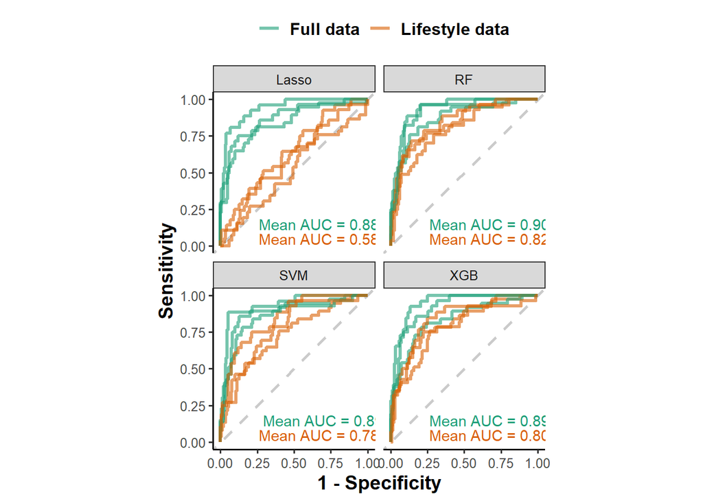

```r
ROC_compare_fold <- probs_new_final%>%
  ggplot(aes(1 - specificity, sensitivity,
             fill = Fold, color=Condition)) +
  geom_abline(lty = 2, color = "gray",
              size = 1,alpha = 0.8) +
  geom_path(alpha = 0.6, size = 1.2) +
  coord_equal() +
  labs(x = "1 - Specificity", y = "Sensitivity") +
  facet_wrap(~ ML) +
    geom_text(data = auc_values_full_mean,
              aes(label = paste0("Mean AUC = ", AUC)),
            x = 0.7, y = 0.15, show.legend = FALSE) +
  geom_text(data = auc_values_life_mean,
            aes(label = paste0("Mean AUC = ", AUC)),
            x = 0.7, y = 0.05, show.legend = FALSE) +
  theme_bw(base_size = 12) +
  theme(legend.position = "top",
        panel.border = element_blank(),  # remove panel borders
        panel.grid.major = element_blank(),  # remove major grid lines
        panel.grid.minor = element_blank(),  # remove minor grid lines
        axis.line = element_line(),  # set axis lines to bold
        axis.text = element_text(),  # set axis text to bold
        axis.title = element_text(size = 14, face = "bold"),  # set axis title to bold
        plot.background = element_blank(),  # remove plot background
        panel.background = element_blank(),  # remove panel background
        legend.text = element_text(size = 12, face = "bold"),  # set legend text to bold
        legend.title = element_blank()  # remove legend title
  ) +
  scale_color_brewer(palette = "Dark2")
print(ROC_compare_fold)
```

# Descriptives Table

Estimates are obtained for all included patients on baseline stats.

```r
full_data <- read_csv("Data/full_data.csv") # raw data set is loaded
# Preparation of dataset needed for descriptive stats
names <- c("patient","Age","Height","Weight","BMI","HbA1c","T2D_Dur")
descriptives <- full_data %>%
  select(patient,Age,Height,Weight,BMI,HbA1c,T2D_Dur)
names(descriptives) <- c(names)

DT <- data.table(descriptives)
DT[, sapply(.SD, function(x) list(mean=round(mean(x), 2))), by=patient]
```

```
##     patient Age.mean Height.mean Weight.mean BMI.mean HbA1c.mean T2D_Dur.mean
##  1:    1001       57         161          96    37.04         48           16
##  2:     601       74         165          75    27.55         66           19
##  3:     605       53         185          73    21.33         51            8
##  4:     606       68         183         116    34.64         59           13
##  5:     607       42         182          93    28.08         51            6
##  6:     608       77         165          90    33.06         94           21
##  7:     609       68         171          88    30.09         57           24
##  8:     611       64         176         101    32.61         58           21
##  9:     616       79         173          94    31.41         54            8
## 10:     617       68         180          81    25.00         53           36
## 11:     618       48         187         111    31.74         74           15
## 12:     621       65         176         110    35.51         57           12
## 13:     624       63         182          97    29.28         50            9
## 14:     628       67         188          78    22.07         50           17
```

[output cut: 63 more lines]

```r
names(DT) <- c(names)
DT <- as.data.frame(DT)
```

## Proportions and counts for factor variables

For factors a different approach is used and values need to be included manually.

```r
table(full_data$Night_class_hypo_out)
```

```
##
##   0   1
## 600 113
```

```r
round(table(full_data$Night_class_hypo_out)[1]/
        (table(full_data$Night_class_hypo_out)[1]+
           table(full_data$Night_class_hypo_out)[2]),3)
```

```
##     0
## 0.842
```

```r
round(table(full_data$Night_class_hypo_out)[2]/
        (table(full_data$Night_class_hypo_out)[1]+
           table(full_data$Night_class_hypo_out)[2]),3)
```

```
##     1
## 0.158
```

```r
table(full_data$Gender)
```

```
##
##   0   1
## 444 269
```

```r
round(table(full_data$Gender)[1]/
        (table(full_data$Gender)[1]+table(full_data$Gender)[2]),3)
```

```
##     0
## 0.623
```

```r
round(table(full_data$Gender)[2]/
        (table(full_data$Gender)[1]+table(full_data$Gender)[2]),3)
```

```
##     1
## 0.377
```

# Latex code for descriptives

```r
stargazer(DT,
          type = 'latex', min.max=FALSE, mean.sd = TRUE,
          nobs = FALSE, median = FALSE, iqr = FALSE,
          digits=1, align=T,
          title = "Summary Statistics")
```

```
##
## % Table created by stargazer v.5.2.3 by Marek Hlavac, Social Policy Institute. E-mail: marek.hlavac at gmail.com
## % Date and time: Do, Mai 11, 2023 - 14:56:57
## % Requires LaTeX packages: dcolumn
## \begin{table}[!htbp] \centering
##   \caption{Summary Statistics}
##   \label{}
## \begin{tabular}{@{\extracolsep{5pt}}lD{.}{.}{-1} D{.}{.}{-1} }
## \\[-1.8ex]\hline
## \hline \\[-1.8ex]
## Statistic & \multicolumn{1}{c}{Mean} & \multicolumn{1}{c}{St. Dev.} \\
## \hline \\[-1.8ex]
## patient & 669.1 & 58.1 \\
## Age & 64.9 & 9.8 \\
## Height & 173.3 & 9.2 \\
## Weight & 91.4 & 14.8 \\
## BMI & 30.5 & 4.9 \\
## HbA1c & 56.7 & 11.9 \\
## T2D\_Dur & 17.7 & 9.9 \\
## \hline \\[-1.8ex]
## \end{tabular}
## \end{table}
```

## Calibration plots - OPTIONAL

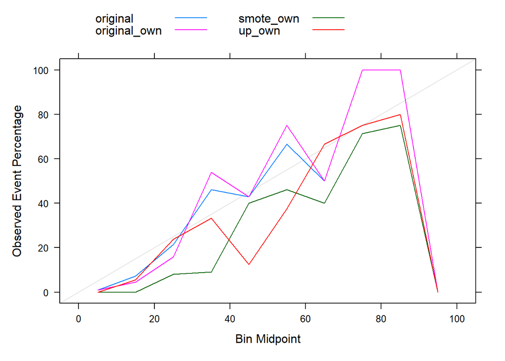

```r
calibration_plots(probabilities_full$rf)
```

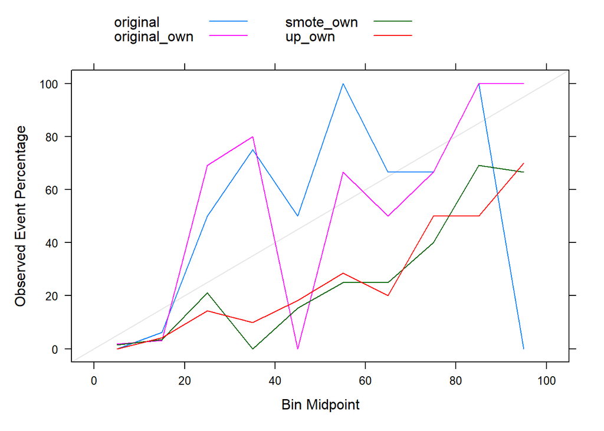

```r
calibration_plots(probabilities_full$svm)
```

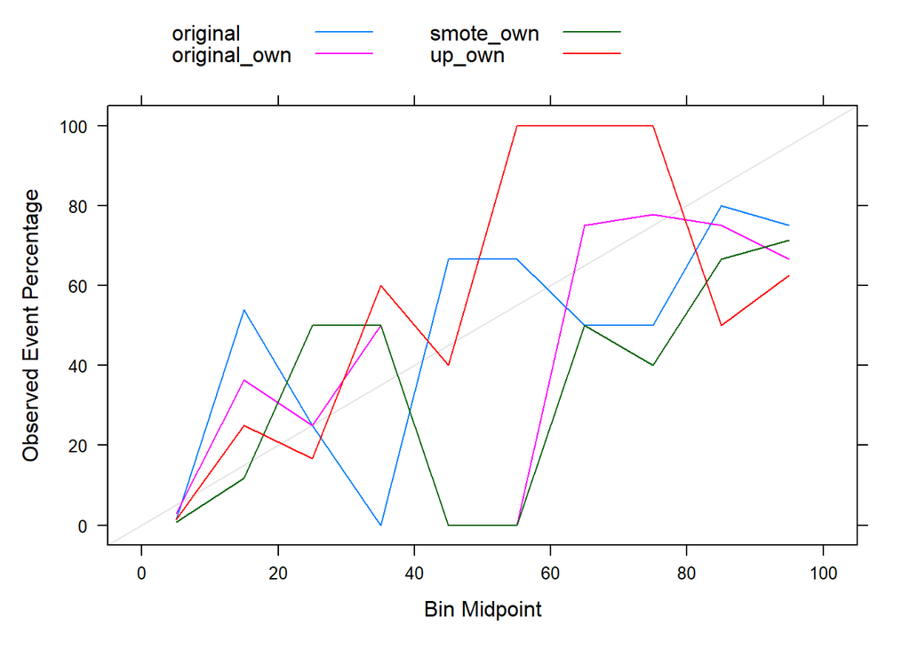

```r
calibration_plots(probabilities_full$xgb)
```

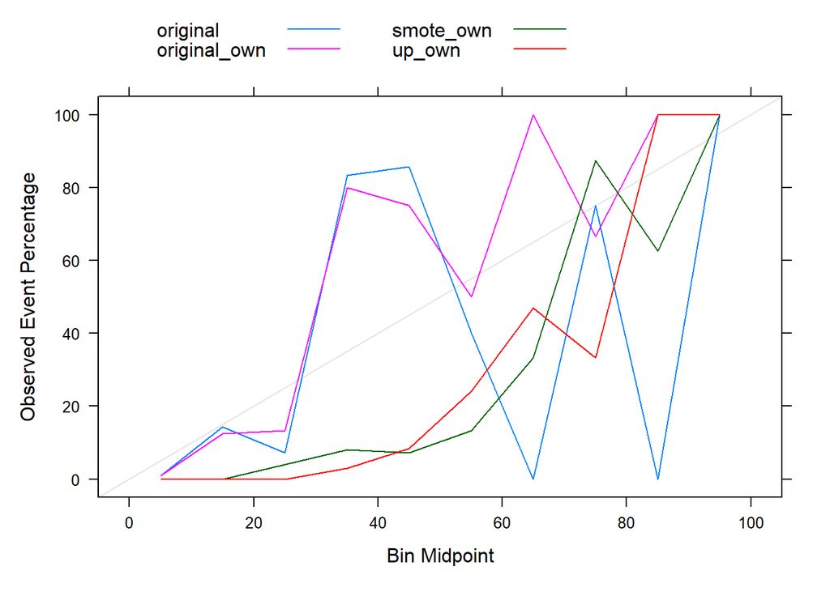

```r
calibration_plots(probabilities_full$lasso)
```

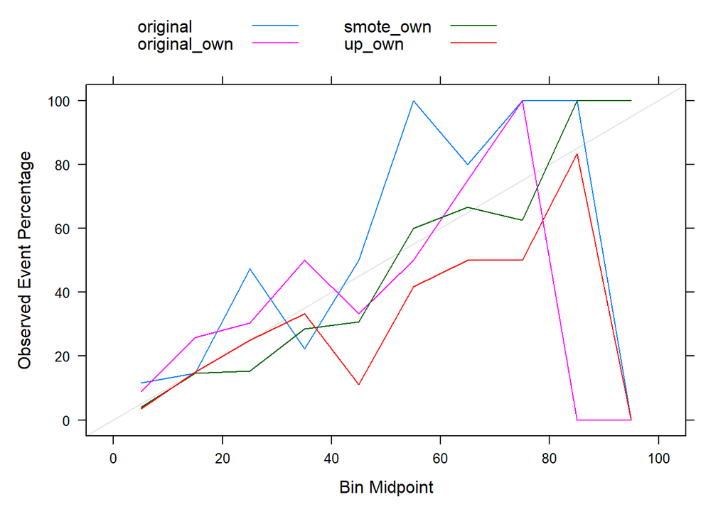

```r
calibration_plots(probabilities_life$rf)
```

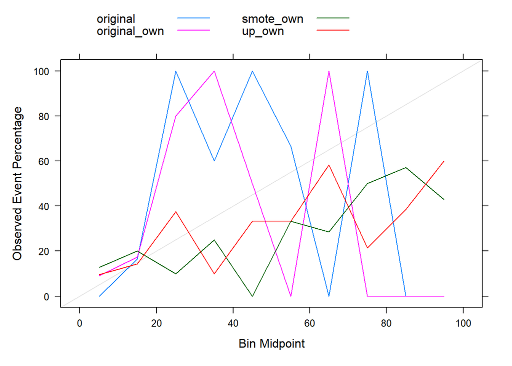

```r
calibration_plots(probabilities_life$svm)
```

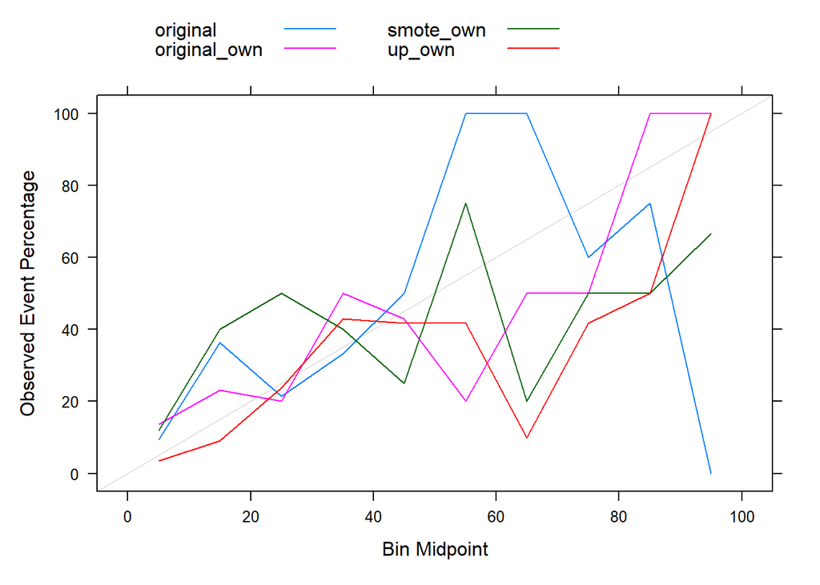

```r
calibration_plots(probabilities_life$xgb)
```

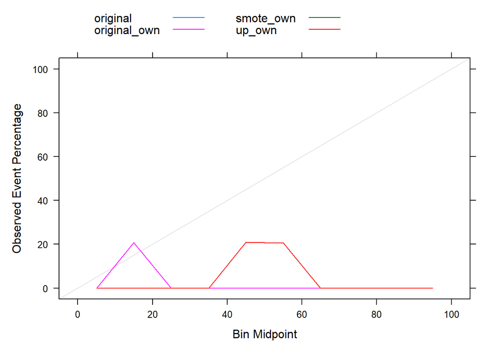

```r
calibration_plots(probabilities_life$lasso)
```

## Outcome frequency and Distribution of days - OPTIONAL INFORMATION

```r
descrip <- full_data
number_of_days_pp <- descrip %>%
  group_by(patient) %>%
  summarise(n= n())
sort(number_of_days_pp$n) # distributions of days per patient
```

```
##  [1]  3  4  4  5  5  5  5  5  5  6  6  6  6  6  6  7  7  7  7  7  8  8  8  8  8
## [26]  8  9  9  9  9  9  9  9  9  9  9 10 10 10 10 10 10 10 10 10 10 10 10 11 11
## [51] 11 11 11 11 11 11 12 12 12 12 12 12 12 12 12 13 13 13 13 13 13 13 14 14 14
## [76] 14
```

```r
nrow(number_of_days_pp) # number of patients
```

```
## [1] 76
```

```r
nrow(full_data) # number of individual observations
```

```
## [1] 713
```

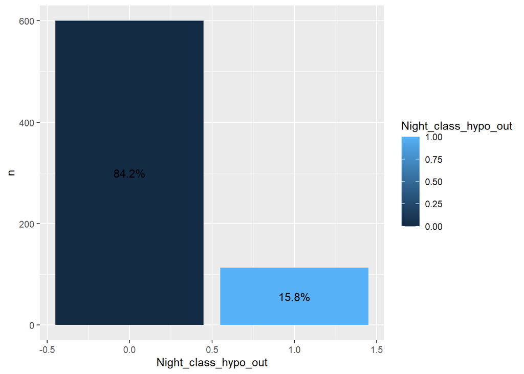

```r
# Visualization for distribution of outcome variable
ggplot(full_data %>%
      count(Night_class_hypo_out) %>% #Groups by team and role
       mutate(pct=n/sum(n)),       #Calculates % for each role
        aes(Night_class_hypo_out, n, fill=Night_class_hypo_out)) +
        geom_col(stat="identity", position="stack") +
  geom_text(aes(label=paste0(sprintf("%1.1f", pct*100),"%")),
            position=position_stack(vjust=0.5))
```

### CGM visualisation

Exemplary continous profiles of patients. Nocturnal Hypo-, and Hyperglyceamia are highlighted. On top it gets clear, where periods of glucose values are missing in the intended 14 day period

```r
all_patients_cgm <- read_csv("~/GitHub/Sweet_Dreams_Ahead_Machine_Learning_Models_for_Nocturnal_Hypoglycemia_Prediction_in_Type_2_Diabetes/Processing_and_Extraction/Data_processed/all_patients_cgm.csv")
```

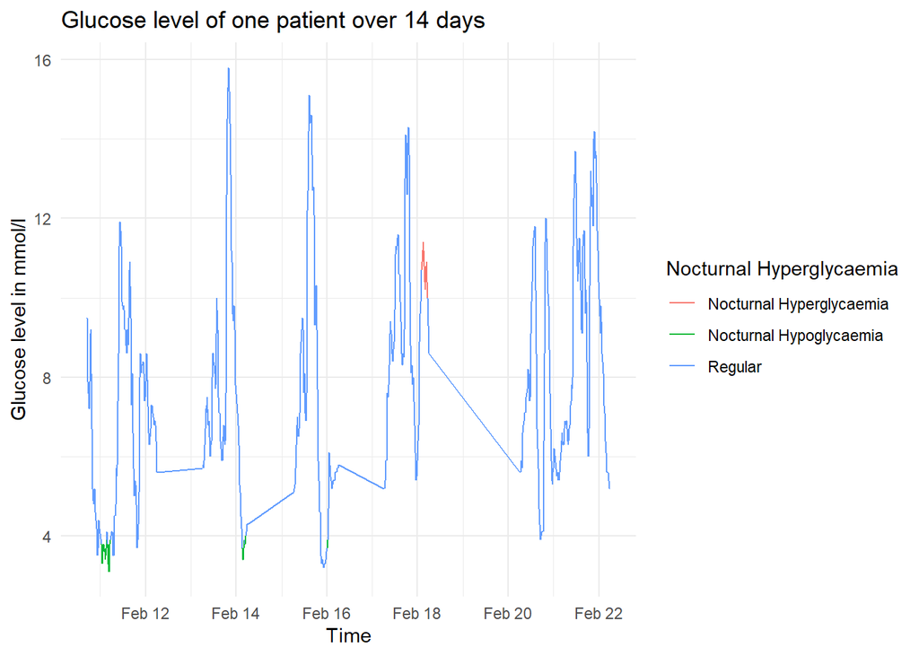

```r
all_patients_cgm %>%
  filter(patient == 761) %>%
  ggplot(aes(x=full_date, y=Historie_glucose, colour=Noc_variability)) +
  geom_line(aes(group =3)) +
  theme_minimal() +
  labs(title = "Glucose level of one patient over 14 days",
       x = "Time",
       y = "Glucose level in mmol/l",
       colour = "Nocturnal Hyperglycaemia")
```

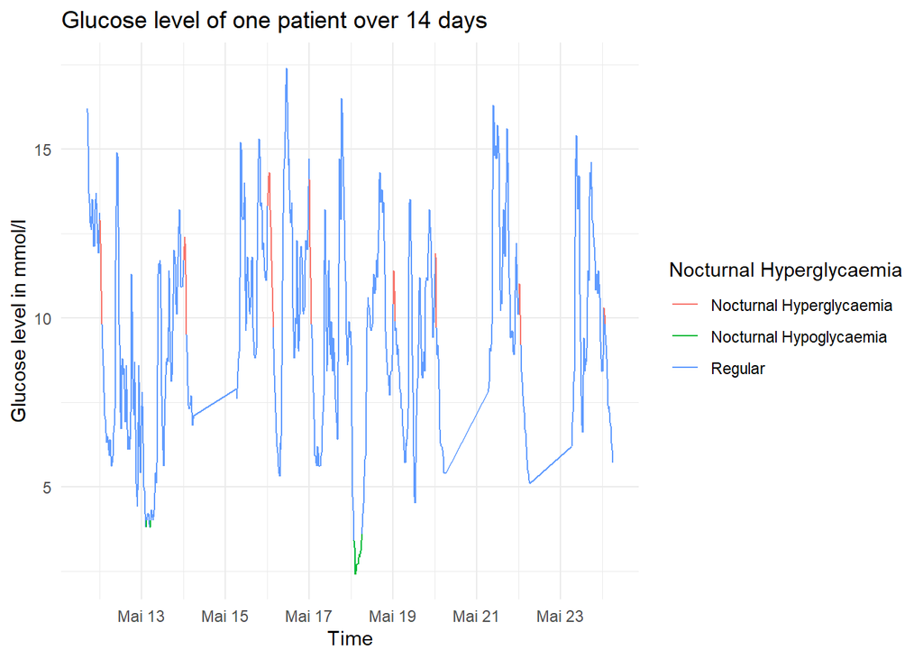

```r
all_patients_cgm %>%
  filter(patient == 601) %>%
  ggplot(aes(x=full_date, y=Historie_glucose, colour=Noc_variability)) +
  geom_line(aes(group =3)) +
  theme_minimal() +
  labs(title = "Glucose level of one patient over 14 days",
       x = "Time",
       y = "Glucose level in mmol/l",
       colour = "Nocturnal Hyperglycaemia")
```